# Discerning Prosper Interest Rates by Abhishek Anirudhan

### INTRODUCTION:

I will be examining a dataset of loans generated by the peer-to-peer lending forum, Prosper between 2006 and 2014. The dataset contains over 100,000 observations described over 81 features.I took up this project with the intention of probing the dataset to discern any interesting patterns and explain them.

#### LOOKING AT MISSING VALUES:

The dataset seemed to contain many NAs, I made some preliminary plots to find out just how many.

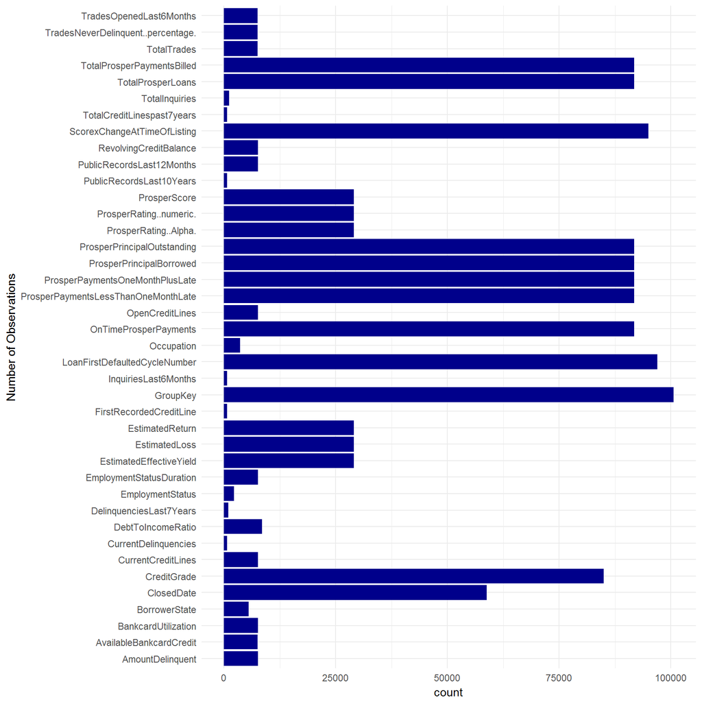

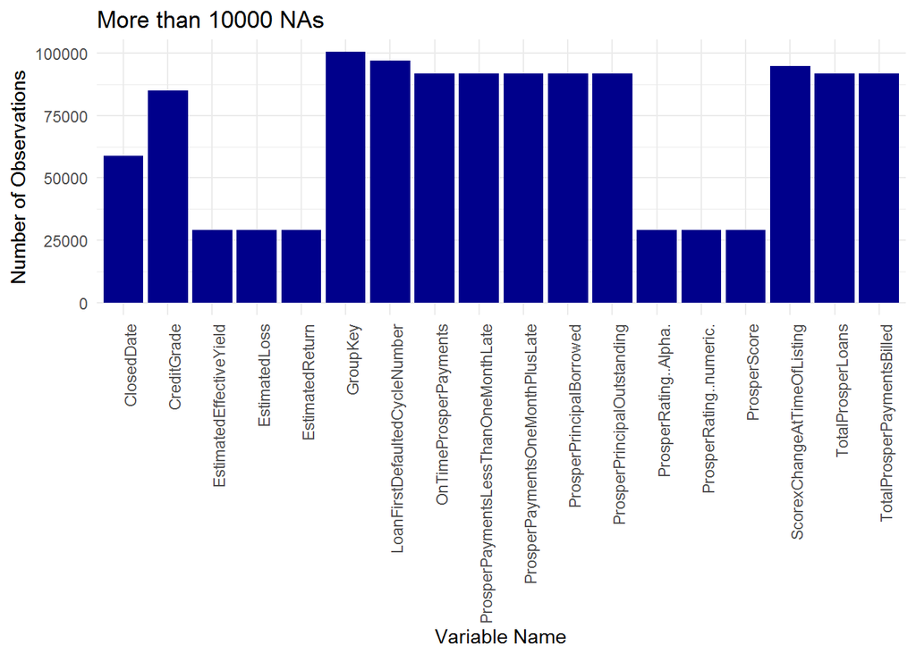

I then proceed to remove these and other variables.

# Univariate Plots Section

The original dataset contained 113,937 observations spread over 81 variables.

```
## [1] 113937     81
```

```
## [1] 113937     26
```

```
##  [1] "ListingNumber"                "ListingCreationDate"
##  [3] "Term"                         "LoanStatus"
##  [5] "BorrowerAPR"                  "BorrowerRate"
##  [7] "LenderYield"                  "ListingCategory..numeric."
##  [9] "IsBorrowerHomeowner"          "CurrentlyInGroup"
## [11] "CreditScoreRangeLower"        "CreditScoreRangeUpper"
## [13] "IncomeRange"                  "IncomeVerifiable"
## [15] "StatedMonthlyIncome"          "LoanMonthsSinceOrigination"
## [17] "LoanOriginalAmount"           "LoanOriginationDate"
## [19] "LoanOriginationQuarter"       "MonthlyLoanPayment"
## [21] "LP_CustomerPayments"          "LP_CustomerPrincipalPayments"
## [23] "LP_InterestandFees"           "LP_ServiceFees"
## [25] "EmploymentStatus"             "LoanPurpose"
```

### BORROWER’S PROFILE

I will begin by exploring the profile of borrowers. As stated the dataset is composed on 113,937 borrowers.

#### INCOME RANGE:

```
##
##             $0      $1-24,999      $100,000+ $25,000-49,999 $50,000-74,999
##            621           7274          17337          32192          31050
## $75,000-99,999  Not displayed   Not employed
##          16916           7741            806
```

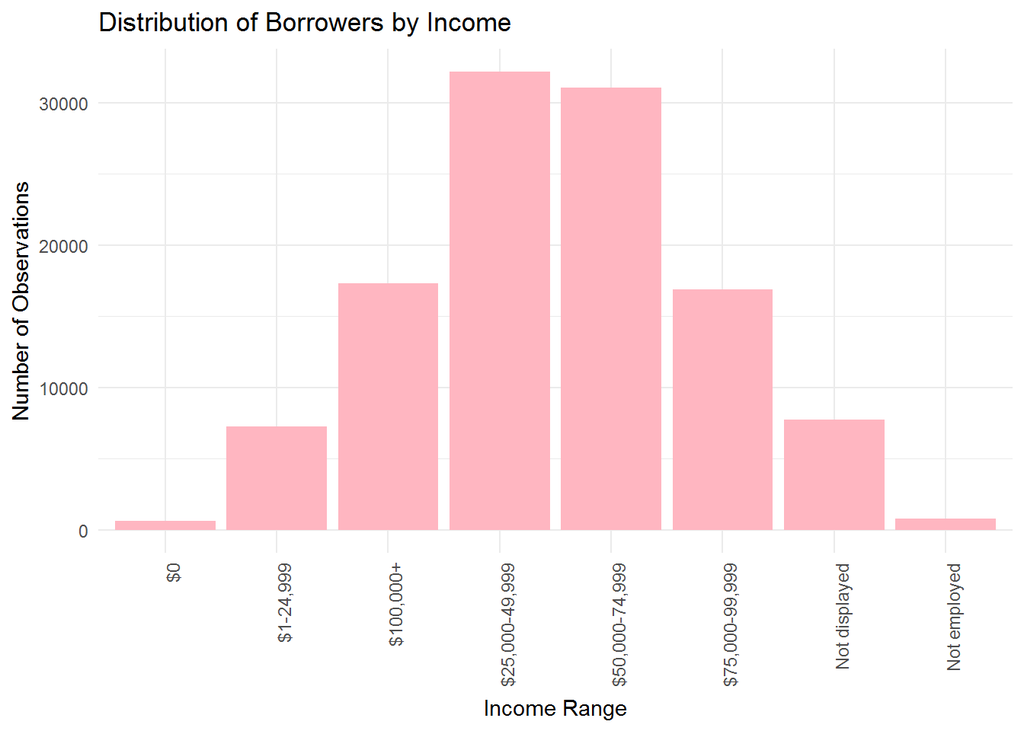

Right away, I can see that the data is not order, I correct for this, and plot the distribution again:

```
## [1] $25,000-49,999 $50,000-74,999 Not displayed  $25,000-49,999
## [5] $100,000+      $100,000+
## 8 Levels: Not employed < $0 < $1-24,999 < ... < Not displayed
```

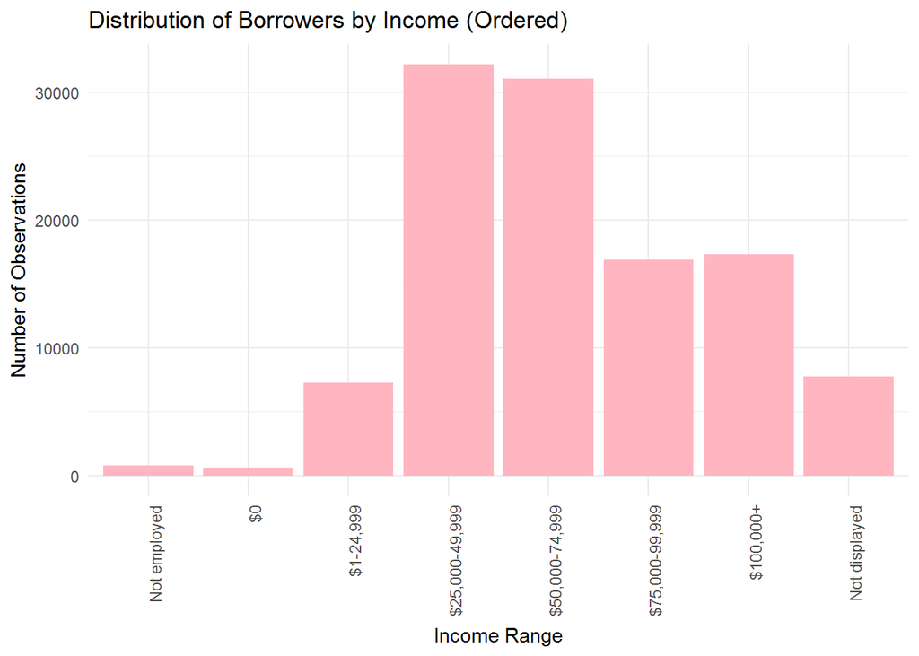

Plotting only declared incomes (USD0 - USD100,000+), I can see that the distribution is approximately normal with most borrowers having incomes close to the middle (between USD25,000 and USD75,000)

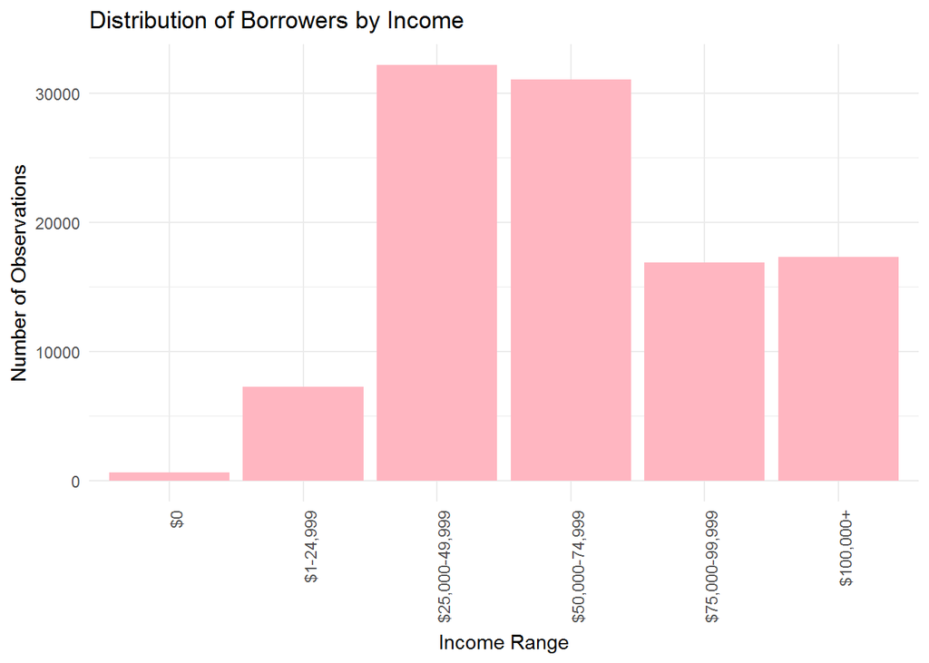

#### MONTHLY INCOMES:

```
##    Min. 1st Qu.  Median    Mean 3rd Qu.    Max.
##       0    3200    4667    5608    6825 1750000
```

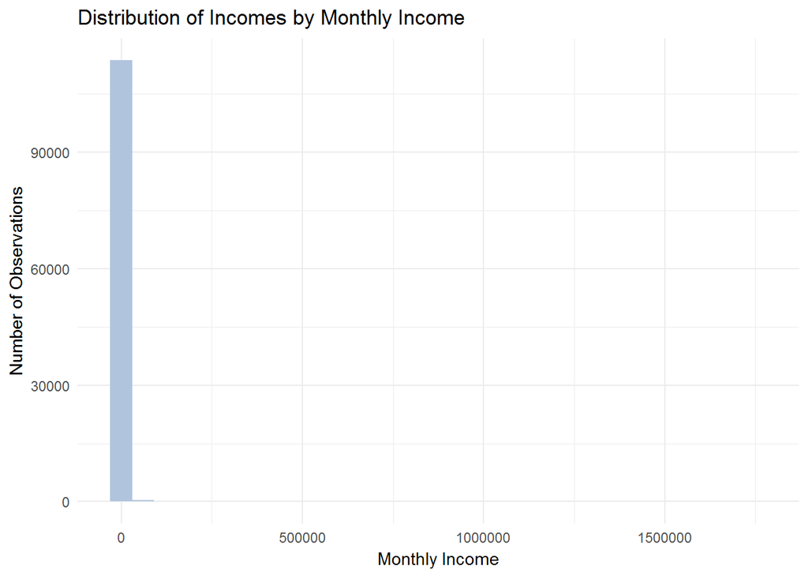

I can see here that the presence of outliers is throwing the distribution off. To correct for this, I will take a look at the distribution without the outliers.

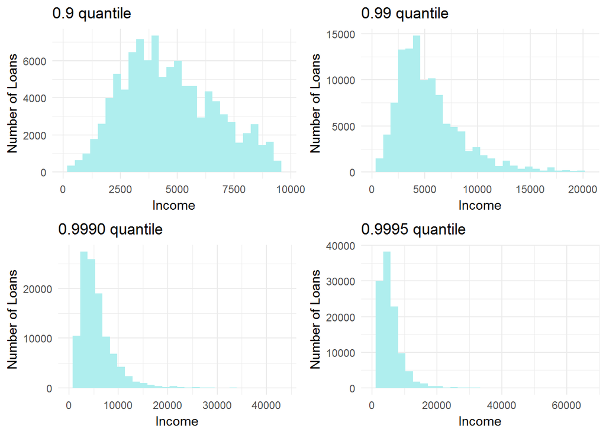

I observe that data upto the 90th quantile is approximately normal, but overall the data has a positive skew. This is expected because most borrowers - especially since they’re borrowers, and hence need tp take out a loan for whatever purpose - have lower incomes.

#### EMPLOYMENT STATUS:

I see most of the people who are granted loans are employed.

```
##
##      Employed     Full-time Not available  Not employed         Other
##         67322         26355          5347           835          3806
##     Part-time       Retired Self-employed
##          1088           795          6134
```

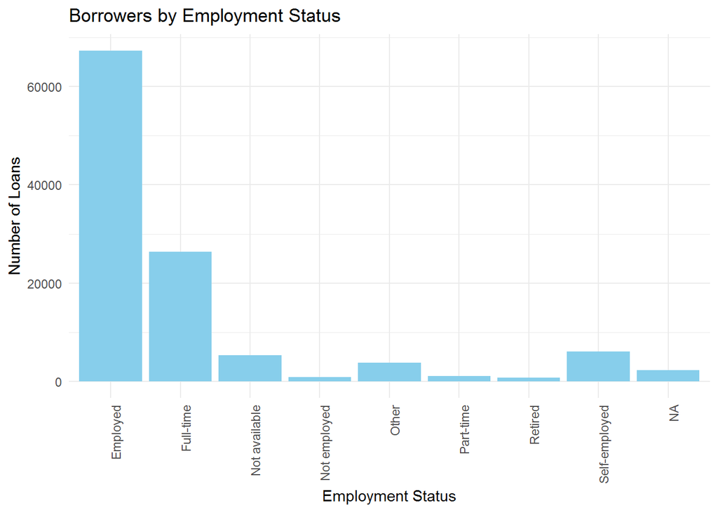

#### HOUSE OWNERSHIP:

About equal number of loans were given to Homeowners as opposed to Non-Homeowners.

```
##
## False  True
## 56459 57478
```

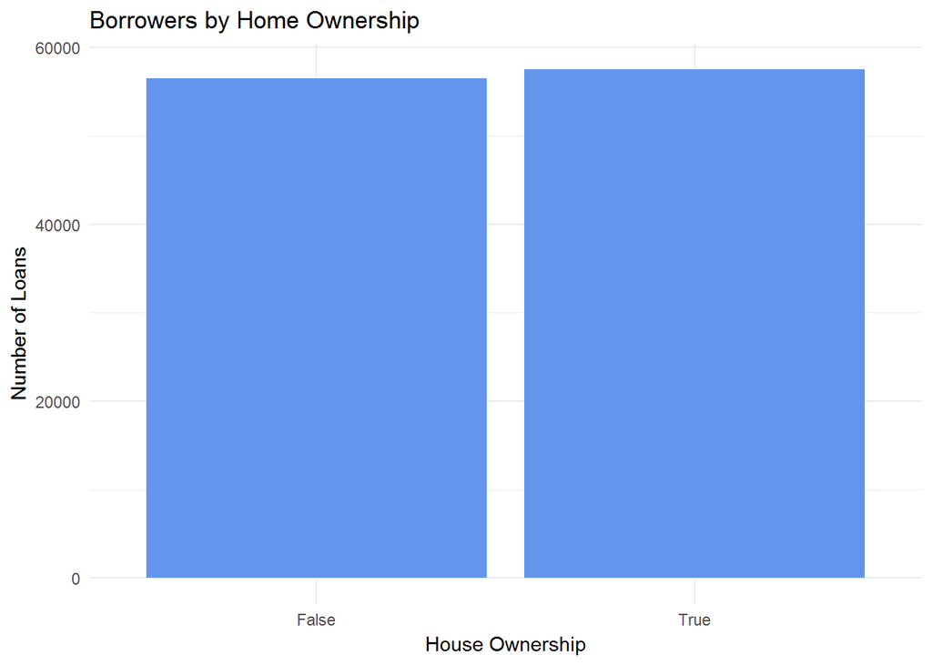

#### CREDIT SCORE:

I see that I have a range (Lower and Upper) of credit scores. Converting these ranges to a single value will be fruitful for further analysis. I have done the same here:

```
## [1] 649.5 689.5 489.5 809.5 689.5 749.5
```

```
##    Min. 1st Qu.  Median    Mean 3rd Qu.    Max.    NA's
##     9.5   669.5   689.5   695.1   729.5   889.5     591
```

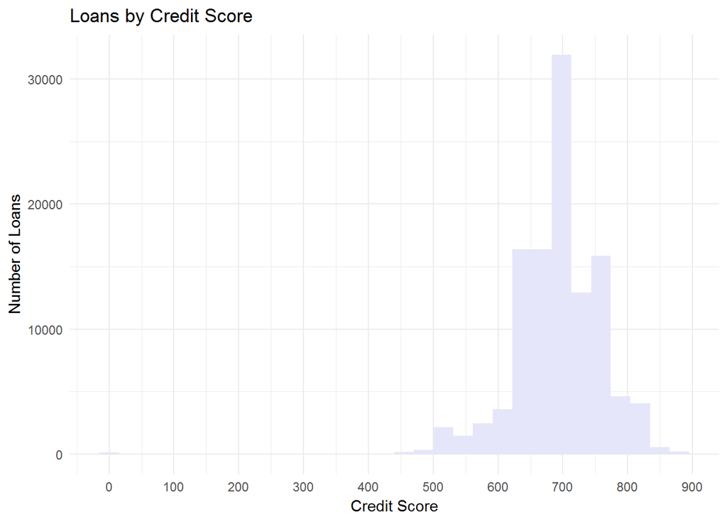

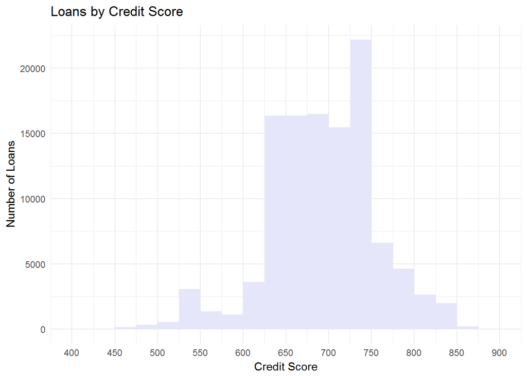

The distribution of credit scores is approximately normal.

### LOAN PORTFOLIO:

I will begin by plotting the distribution of the loan amounts. I observe that the distribution has a positive skew:

```
##    Min. 1st Qu.  Median    Mean 3rd Qu.    Max.
##    1000    4000    6500    8337   12000   35000
```

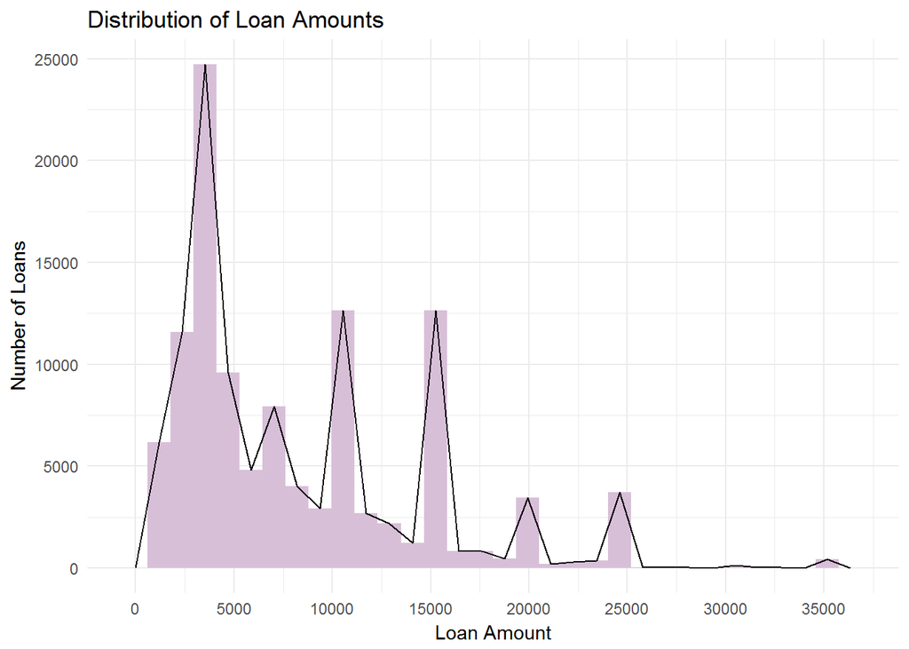

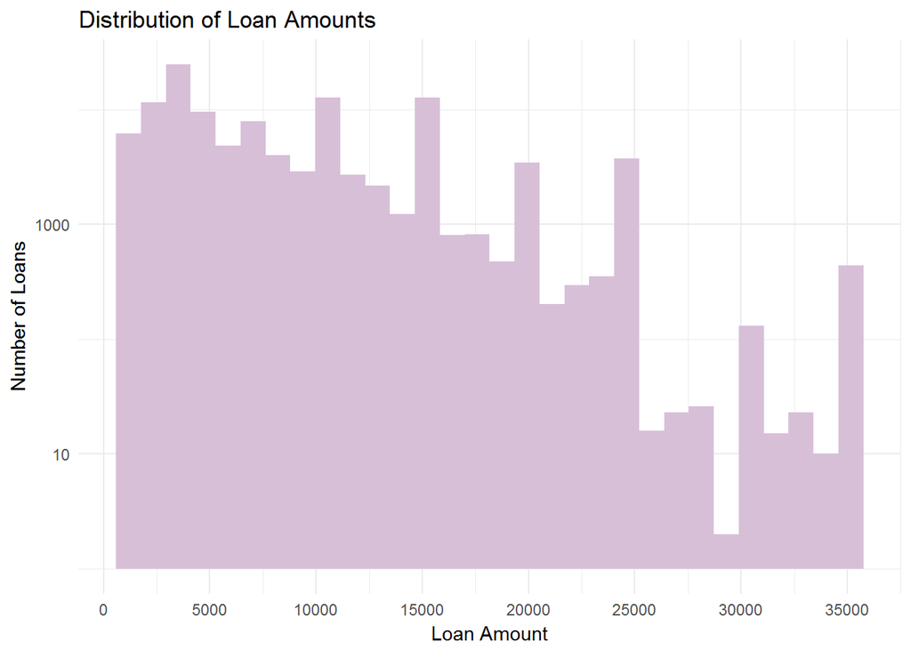

#### LOAN STATUS:

```
##
##              Cancelled             Chargedoff              Completed
##                      5                  11992                  38074
##                Current              Defaulted FinalPaymentInProgress
##                  56576                   5018                    205
##   Past Due (>120 days)   Past Due (1-15 days)  Past Due (16-30 days)
##                     16                    806                    265
##  Past Due (31-60 days)  Past Due (61-90 days) Past Due (91-120 days)
##                    363                    313                    304
```

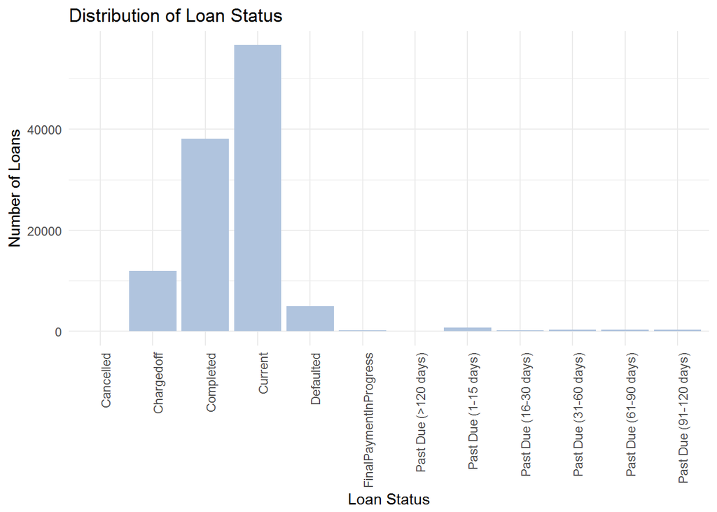

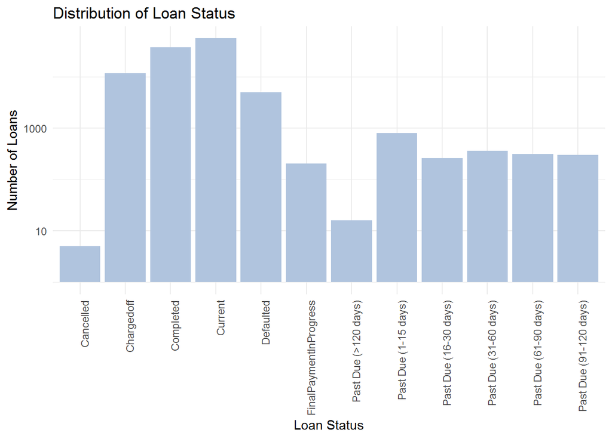

#### LOAN TERM:

I see that most people either apply for or are granted loans for a duration of 36 months or 3 years, followed by durations of 60 months or 5 years, and 12 months.

```
##
##    12    36    60
##  1614 87778 24545
```

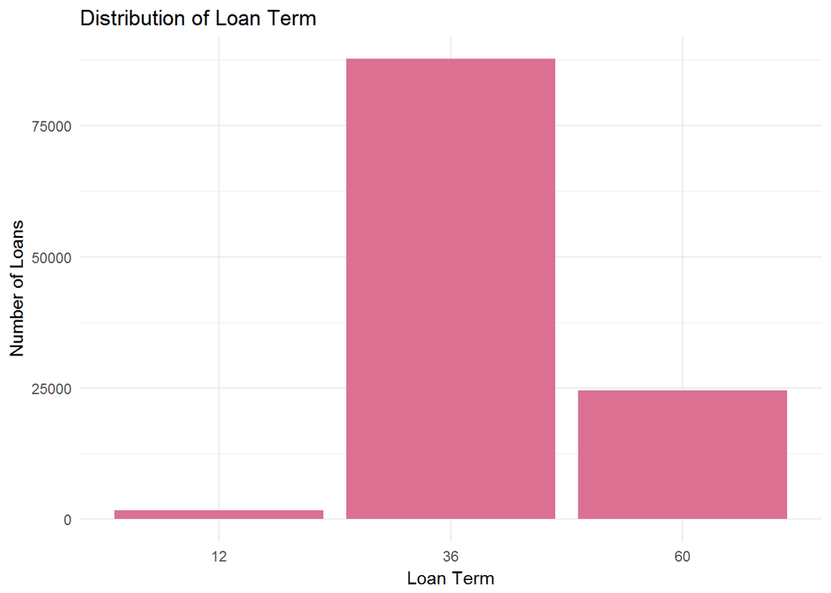

#### LOAN PURPOSE:

I see that most people borrow for Debt Consolidation. (I was pretty surprised at some of purposes listed!)

```
##      Not available Debt consolidation   Home improvement
##              16965              58308               7433
##           Business      Personal loan        Student use
##               7189               2395                756
##               Auto              Other  Baby and adoption
##               2572              10494                199
##               Boat Cosmetic procedure    Engagement ring
##                 85                 91                217
##        Green loans Household expenses    Large purchases
##                 59               1996                876
##     Medical/dental         Motorcycle                 RV
##               1522                304                 52
##              Taxes           Vacation      Wedding loans
##                885                768                771
```

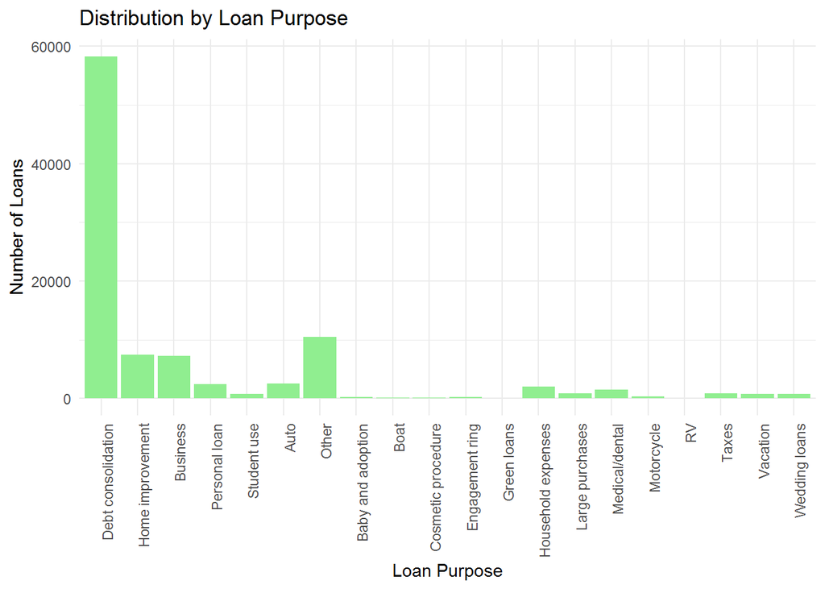

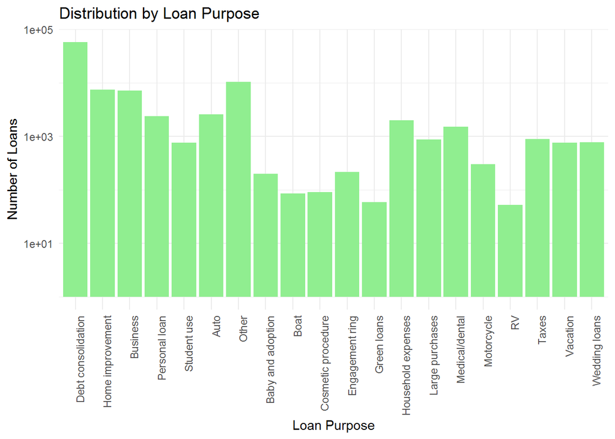

#### BORROWERS RATE:

Next, I take a look at the base interest rate offered to borrowers. Right of the bat, I can see that there’s a difference in the rates offered to borrowers. The minimum rate offered was 0% and the maximum rate offered was 49.75%. I wonder what determines the rate of interest offered to a borrower?

```
##    Min. 1st Qu.  Median    Mean 3rd Qu.    Max.
##  0.0000  0.1340  0.1840  0.1928  0.2500  0.4975
```

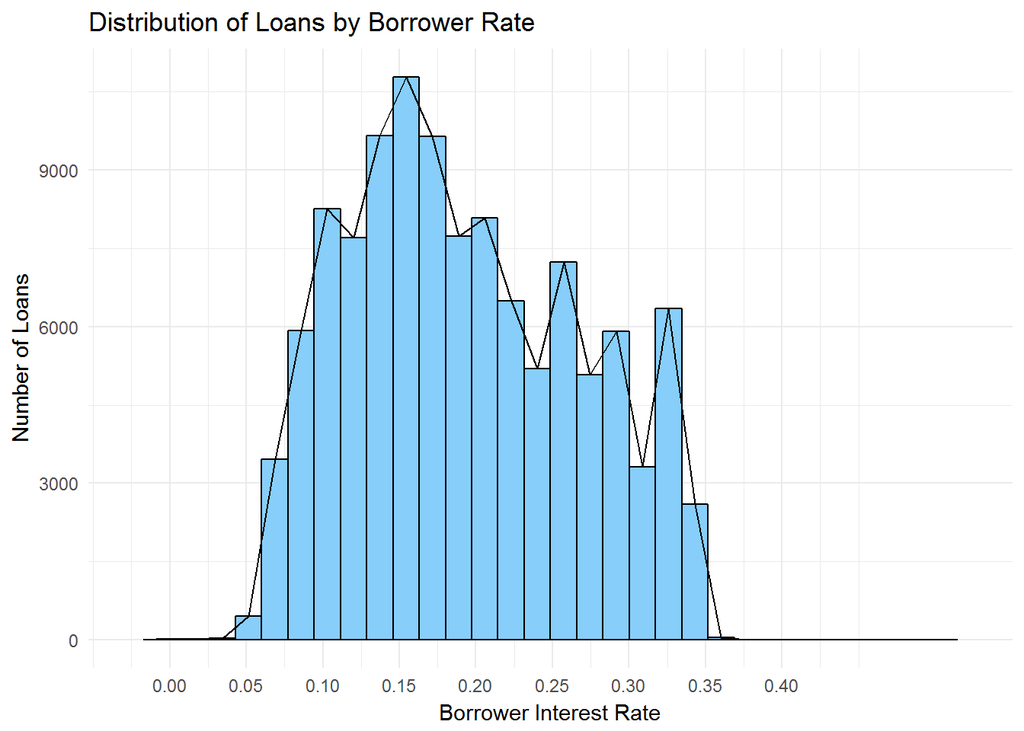

I will look at the loan count over time.

To make it easier to work with dates, I’m going to store the Loan Origination Date in the yyy-mm-dd format.

```
## [1] "2007-09-12" "2014-03-03" "2007-01-17" "2012-11-01" "2013-09-20"
## [6] "2013-12-24"
```

At the first glance, I see that the plot of the number of loans made overtime has a gap - where no loans were made - from late 2008 to early 2009. This coincides with the unfurling of the Great Recession, when lender confidence brokedown and credit markets froze in the United States.

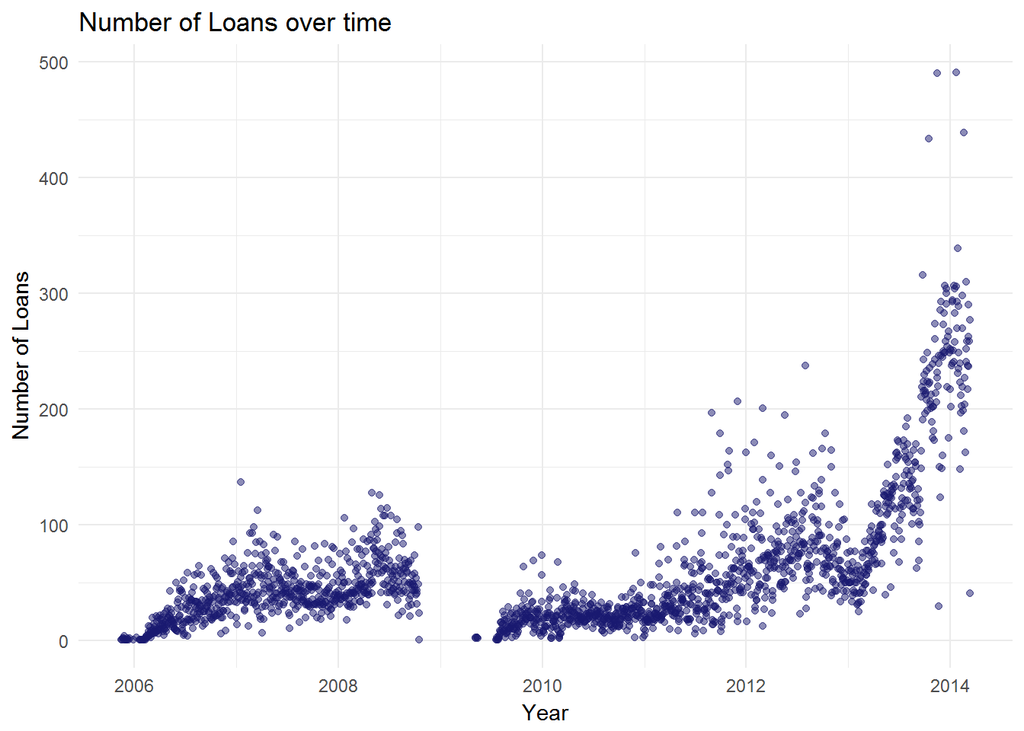

# Univariate Analysis

### What is the structure of your dataset?

The dataset has 113937 observations, and 81 variables.

### What is/are the main feature(s) of interest in your dataset?

The primary feature of interest in my data set is the interest rate: Borrower Rate. I observed that borrowers were offered different interest rates. I am interested in understanding what goes into calculating the rate of interest.

### What other features in the dataset do you think will help support your investigation into your feature(s) of interest?

I know that the interest rate depends on how much of a risk the borrower is considered to be. A higher risk means a higher interest rate. So I will look at features that help me evaluate the risk profile.

These include:

Discrete: Income Range, Employment Status, Loan Purpose Continuous: Monthly Income, Credit Score (Mean), Loan Amount

### Did you create any new variables from existing variables in the dataset?

Yes, I calculated the Mean Credit Score from the Upper and Lower ranges of borrowers credit score.

### Of the features you investigated, were there any unusual distributions? Did you perform any operations on the data to tidy, adjust, or change the form of the data? If so, why did you do this?

I used a log10 tranformation on the y-axis of plots where the data was either long tailed or had high variance to view the distibution better.

One plot that stood out was that of StatedMonthlyIncome. The distribution was not very telling because of the presence of outliers. I limited the axes to get a zoom in on the bulk of the data.

# Bivariate Plots Section

When I plot the borrowers rate over time, I get a very noisy plot. This is because we have data per day, and the daily average tends to move around a lot. To get a clearer picture, I plot the average rate per year, this smoothens the curve out. It looks like the rates were on the rise till 2011, and then begin a gradual fall.

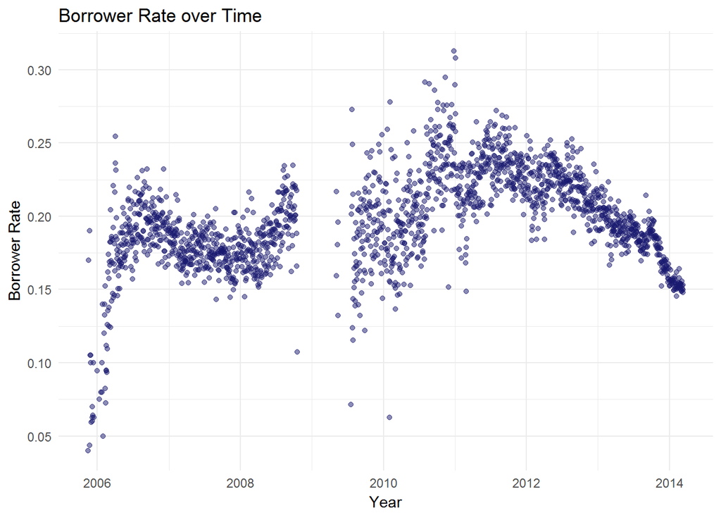

From the above two graphics, I see that there exists a negative relationship between the Number of Loans taken out and the interest rate. This is an intuitive fact: As the cost of borrowing goes up, less number of people borrow.

I would like to quantify this relationship in the Prosper Data Set.

```
##
##  Pearson's product-moment correlation
##
## data:  pld2_by_date$average_rate and pld2_by_date$count
## t = -5.822, df = 1871, p-value = 6.828e-09
## alternative hypothesis: true correlation is not equal to 0
## 95 percent confidence interval:
##  -0.17761353 -0.08863637
## sample estimates:
##        cor
## -0.1333937
```

The coefficient is neglgible.

I will continue with my exploration of the Borrower Rate.

On plotting the daily average borrower rate, I get a very noisy plot - which is typical interest rate behaviour. But, not much is discernible from this plot. Except, I see that the borrower rate was excessively volatile in the period from mid 2009 - 2011.

To get a sense of the long-run trend in the borrower rate, I plot the yearly average.

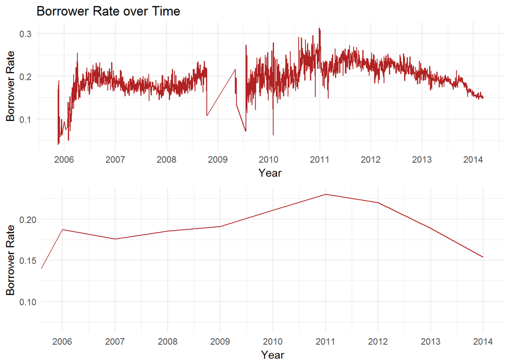

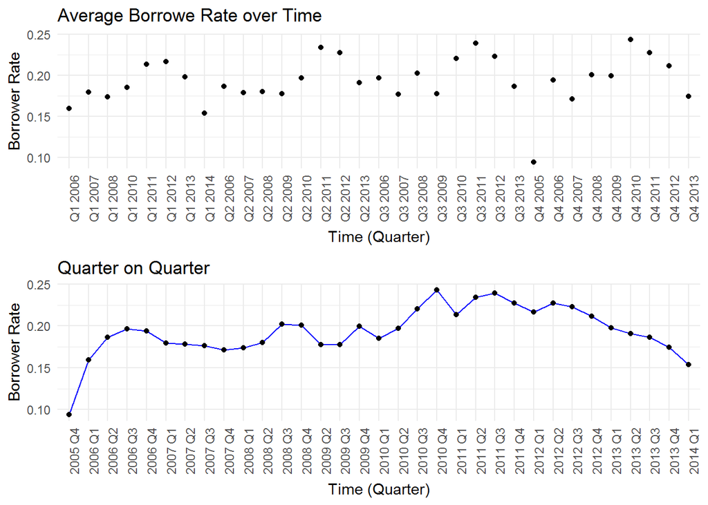

#### BORROWER RATE BY EMPLOYMENT STATUS

Looking at the below charts, I can see that people who are unemployed tend to get a higher rate of interest. This is consistent because interest rate is a compensation for risk, and unemployed people pose a higher risk for lenders.

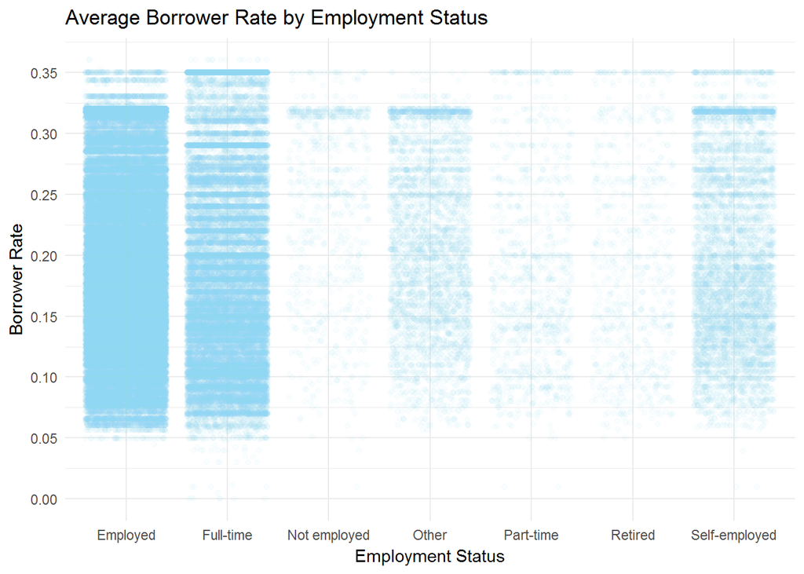

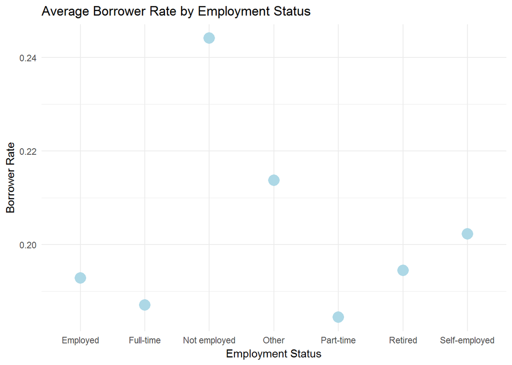

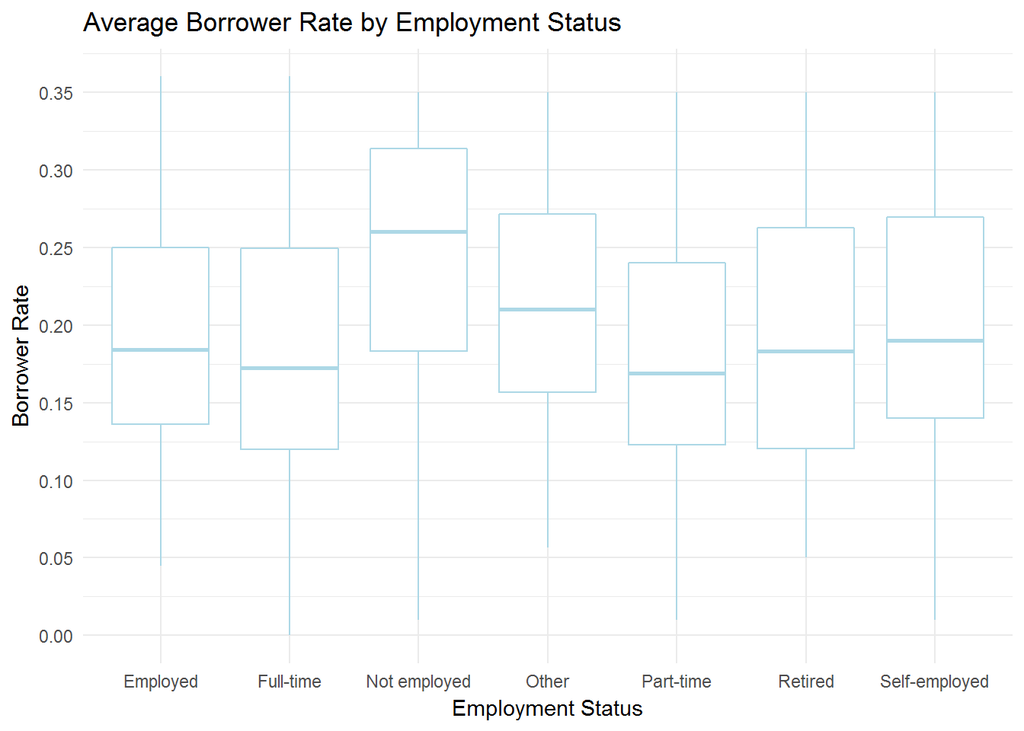

#### HOMEOWNERSHIP AND BORROWER RATE:

I see that people who were not homeowners were stuck with higher borrower rates on average compared to homeowners. This is probably because homeowners have a stable security as collateral.

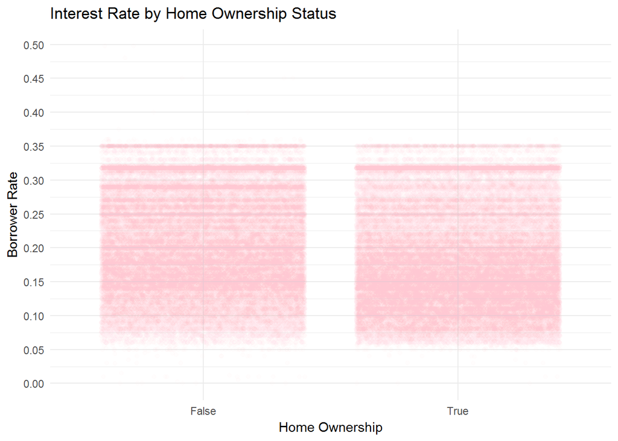

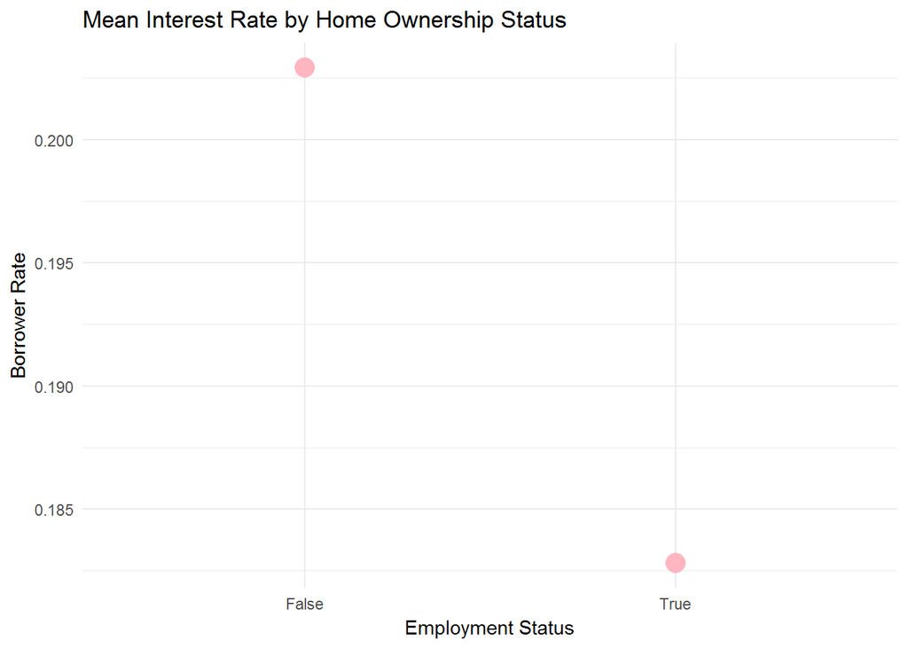

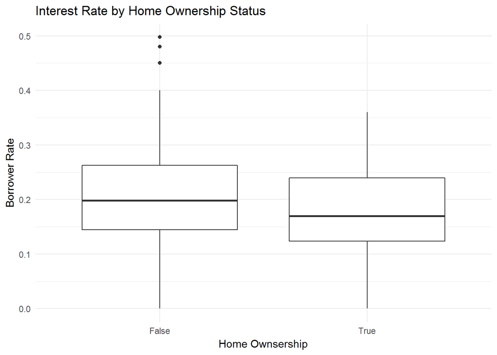

#### LOAN AMOUNT, CREDIT SCORES, INCOME AND BORROWER RATE:

Below are the continuous variables under consideration. I plotted them in a scatterplot matrix.

Maybe the Borrower Rate is determined by a combination of these factors, and taken alone neither of these variables can explain away Borrower Rates.

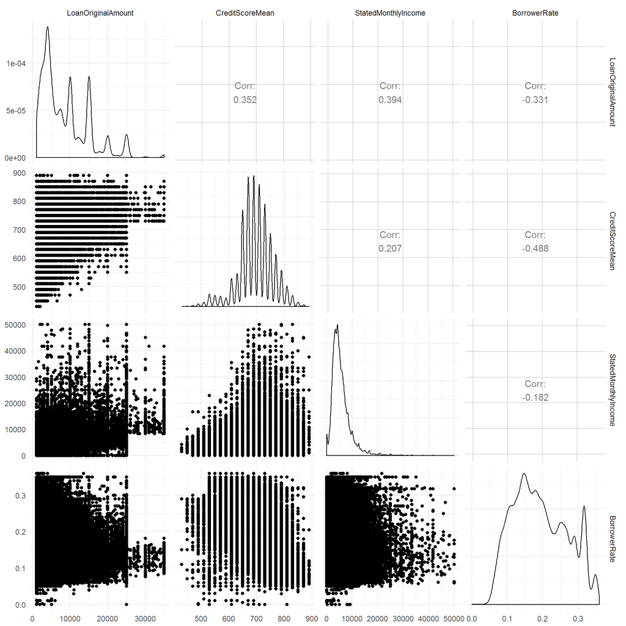

#### WHAT DOES PROSPER ASK FOR A CUSTOM RATE?

I went to Prosper’s website to see how exactly the borrower rate is determined. Prosper prompts the user to enter information relating to four variables in our data set:

1. The Loan Amount required
2. Borrower’s Income
3. Employment Status
4. Purpose of the Loan

I have already explored these variables above, but I think it would be telling to plot them in one matrix.

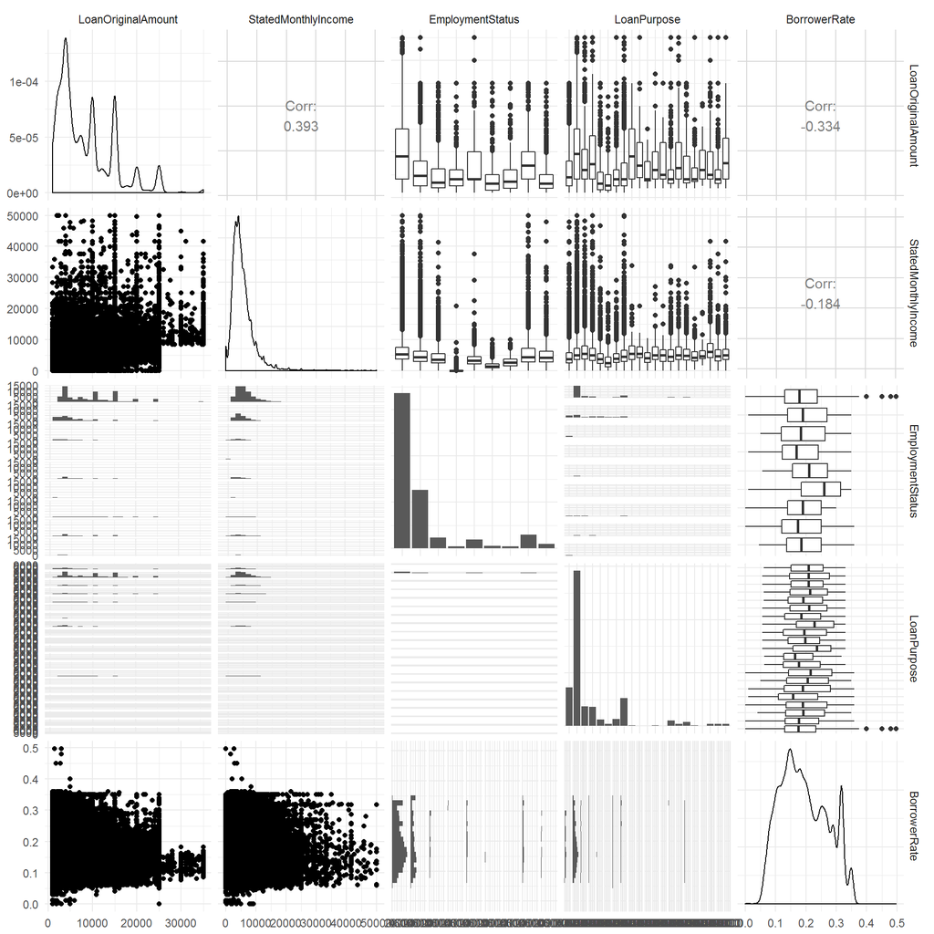

# Bivariate Analysis